# In what trauma patient subgroups are oppotunities for improvement most frequent?

George Sandelswärd

# Abbreviations

• AIS - The Abbreviated Injury Scale • ISS - The Injury Severity Score • LMIC - Low and middle income countries • M&M - Morbidity and Mortality Conferences • NISS - The New Injury Severity Score • OFI - Opportunity for improvement • SweTrau - The Swedish trauma registry • TQIP - Trauma Quality Improvement Program

Introduction: Trauma represents 9% of the annual global deaths and is the most common cause of death in people <45 years. Trauma patients constitute a heterogeneous group with a large variety of injuries. This variety demands specific guidelines for treating all the different trauma subgroups. It is however poorly understood how the potential for trauma care improvement varies between these subgroups. One measure for this is Opportunity for improvement (OFI).

Aims: In this study we assessed the OFI frequency in the clinically important trauma subgroups; men and women, blunt and penetrating trauma, minor and major trauma, and most severely injured body region.

Material and methods: A registry based cohort study using the trauma registry and the trauma quality database at the Karolinska University hospital in Solna. 11864 patients included in the registries between 2014-2021 were screened against the inclusion criteria. The exclusion criteria was patients <15 years or missing necessary information.

Conclusion: Our results suggest that OFI varies between trauma subgroups and that some subgroups have significantly higher OFI than baseline.. Further research is however needed to identify what kind of OFIs that are more frequent in different cohorts and to identify potential risk factors for OFI.

.

Keywords: Trauma subgroups, Opportunity for improvement, Abdominal trauma, OFI

# Introduction

Trauma is defined as the clinical entity composed of physical injury and the body’s associated response and is one of the leading causes of mortality and morbidity in the world accounting for about 9 % of annual global deaths.(1,2) Among people under the age of 45 trauma is the most common cause of death. Over the last decade almost 50 million people worldwide have died from trauma (2).

Not only does trauma represent a large share of the global mortality, but studies have also shown a significant difference in outcome depending on where patients are treated. It has for example been shown that trauma patients in Sweden who were treated at a trauma center had a 41 % lower 30-day adjusted mortality rate compared to patients treated at a non-trauma center (3).

Some studies indicate that the number of trauma-related deaths that potentially could have been prevented are as high as 20 to over 50 %, while for example the rate of preventable deaths at the Karolinska University hospital trauma center was shown to be 4.0 % (4–6). Preventable deaths varies not only between trauma centers and non-trauma centers. There is a significant difference between high income counties and low and middle income countries (LMICs). It is estimated that 2 million lives could be saved annually if LMICs and high income countries had equal fatality numbers for severe injuries (7).

## Trauma quality improvement

Health care quality has been a topic for research for over 100 years. However, in the early research the focus were mainly on standards of performance connected to the skill levels of individual physicians. This meant that when faults were made, answers were sought for in individuals rather than in the systems.(8)

In the 1980s the focus shifted and terms like Trauma Quality Management and Continuous Quality Improvement were introduced. These programs lead to a more management focused approach and was involving all individuals in the work for improved health care quality. This shift also meant a more continuous evaluation of the health care, leading to the possibility for quality defects to be addressed more efficiently.(8)

Since the early 2000s a term called Quality Improvement is used. Quality Improvement has a more multidisciplinary focused approach with Morbidity and Mortality conferences as an essential part. Quality improvement also further emphasizes the role of systems rather than individuals’ clinical performances, as systems are more accountable to outcomes.(8)

In the past decades several trauma quality improvement programs (TQIP) have been created. One of the more established ones is the TQIP by the American College of Surgeons that was launched in 2008 (9). The American College of Surgeons’ TQIP provides site-specific data of how well each hospital performs in terms of trauma care. This makes it possible to compare data from hospitals with data from other hospitals of the same level, leading to changes in routines and practice guidelines (10).

## Morbidity and Mortality Conferences

An important part of trauma care evaluation and improvement is Mortality and Morbidity Conferences (M&M). This is a multidisciplinary conference with representatives from all medical specialties and professions in the trauma team. The purpose of M&M is to learn from the care provided, identify opportunities for improvements, and implement corrective actions(11). As it is not possible to analyze every trauma case in detail audit filters are often used to decide which cases that are to be reviewed at M&M (12).

Audit filters can be described as predefined statements that decides whether or not the care of a specific patient deviated from set norms (13). Such audit filter can be time frames in which a test should be taken or a Glascow Coma Scale score under 8 without the patient being indubated(12).

## Trauma Severity Scores

The Abbreviated Injury Scale (AIS) defines traumatic injuries across 9 different body regions. The scale ranges from 1-5, where 1 is the least serious and 5 the most serious (14).

The Injury Severity Score (ISS) is an anatomic severity scale developed to assess multiple-injured patients. The ISS assigned to a patient is calculated based on the AIS points from the injured body regions. The higher ISS the more serious trauma the patients suffers from. The score is calculated by squaring the AIS scores of the three most injured body region and then adding them together. As the AIS ranges from 1-5, the ISS has a span between 1-75. The ISS does however only take into account the most severe injury in each body region, meaning that you could have two different injuries in the abdomen without it affecting the ISS score.(15)

The New Injury Severity Score (NISS) was developed from the ISS. NISS also takes injuries from the same body regions as ISS into account. The NISS is the sum of the squares of the three highest AIS codes in these regions, meaning that all three injuries can be in the same region or in separate regions. As the AIS can vary from 1-5, the NISS ranges between 1-75 (16). The NISS score is also used internationally to define trauma severity. A NISS Score >15 is considered a major trauma and <15 a minor trauma (17).

## Opportunity for improvement

Opportunity for improvement (OFI) is defined as when the trauma care for a patient does not match best practices in at least one aspect. Whether there is opportunity for improvement in the care of a specific case or not is decided during M&M where selected trauma cases are reviewed. Examples of OFI could be too long transportation time to the hospital from the site of injury, insufficient vital signs documentation in the emergency department or missing trauma surgeon/consultant.(18)

OFI can be a more nuanced measure for trauma care improvement than the more established terms preventable deaths and non preventable deaths. This is because there can be OFI in a case where a patient has died, even if the death was not preventable (19). Furthermore there is no consensus for classification of preventable and non preventable death, leading authors to use different classifications (20). The term OFI also has the advantage over the term preventable death by sounding more positive and encouraging, preventing review board members from having to classify colleagues patient care as inappropriate (18).

## Trauma subgroups

As trauma patients is a heterogeneous group, it is important to have a sufficient understanding of trauma care quality for the different trauma subgroups.(21). Some examples of subgroups are men and women, blunt and penetrating trauma, geriatric, major and minor trauma and traumatic brain injury (22).

In Sweden almost two thirds of trauma patients are men and just over 60% are in the age between 18-64. For example, traumatic injuries from stabbing and from shooting violence are more common in men while women are over represented in fall traumas. (22).

With this wast variety of injuries in a heterogeneous patient group comes a large span of difficulties and problem areas in terms of trauma care (23). The most common cause of death after trauma is hemorrhage (24). Among patients with hemorrhage, problems in decision making, technical skills and making decisions between surgery and radiology are some of the OFIs that have been identified.(23).

The heterogeneity can further be illustrated by pointing at the differences in distribution of preventable death among trauma patients. For example, there are several studies showing that old age increases the risk for preventable death and mortality after trauma (25–27). Major trauma has also been found to have a higher preventable death then minor trauma(28,29).As the problem areas and the frequency of preventable death varies between subgroups it is possible that OFI frequency also differs between subgroups.

## Knowledge gap

There is a lot of available data about subgroups regarding transportation time to hospital, NISS score at the emergency department, rehabilitation, morbidity and mortality rate to state a few examples(22). Despite having all this data, and studies showing varying quality of trauma care between subgroups, knowledge regarding OFI patterns among different trauma subgroups remains unknown. To find out which trauma subgroups that has the most potential for care improvement and to to understand how OFI is distributed in trauma patients, a study looking into OFI frequency between trauma subgroups is needed.

## Aim

In this study we aim to assess the frequency of opportunity for improvement in the following important clinical subgroups: men and women, blunt and penetrating trauma, minor and major trauma, and the most severely injured body region.

# Materials and Methods

## Study design

In Sweden there is a national trauma registry (SweTrau) that includes records of trauma cases from 48 out of 49 hospitals who receives major trauma. To meet the inclusions criteria for SweTrau you must be over 15 years of age, been exposed to a traumatic event leading to trauma team activation, or have a NISS over 15 without trauma team activation. SweTrau also includes patients transferred to a hospital within 7 days of a traumatic event with NISS over 15. (30)

This is a registry based cohort study that uses data from two different Swedish trauma registries. The first registry is the trauma registry at the Karolinska University Hospital in Solna. This registry is a part of SweTrau and contains patients from the years 2014 to 2021. The second registry is the the trauma care quality database which is a subset of the Karolinska University Hospital Trauma Registry.

The trauma quality database includes patients selected for review between 2014 and 2021. These registries were merged and a complete case analysis was done. The frequency of OFI across different subgroups were calculated as were the differences in frequencies between non-overlapping subgroups. Bootstrapping was then used to estimate the confidence intervals these frequencies and differences.

## Setting

The Karolinska University Hospital in Solna, Stockholm is the largest trauma centre in Sweden. The hospital is also classified as a level 1 trauma center.(31) The trauma center at the Karolinska University Hospital in Solna handles about 1800 trauma cases every year, out of which about 200 are children. The Karolinska University Hospital is the primary trauma center for a population of 2,8 million people.(33)

Trauma patients are divided into priority one and two by the paramedics using certain criteria, such as trauma mechanism, GCS points and blood pressure. The trauma team at Karolinska Solna only handle those who are classified as a priority one.(34)

A trauma priority one is considered directly life threatening. Therefore when arriving to Karolinska Solna every patient is taken care of by a full trauma team. This team consists of a trauma leader who is a general surgeon or a resident in general surgery and an anesthetist with a nurse specialized in anesthesiology. The team also has an orthopedic surgeon, radiologist, radiology nurse, emergency medicine nurse, surgical nurse and assistant nurses.(34)

## Participants

All patients are from the Karolinska University Hospital trauma registry and from the Trauma Quality Database. To be eligible for the study all patients had to meet the following inclusion criteria: Patients over 15 year old. If information was missing for age, gender, OFI, trauma mechanism, NISS, AIS code or 30-day survival the patient was excluded.

## Variables and data sources/measurements

There are several steps in the filtration of which patients that should be reviewed at a M&M to detect OFIs. Audit filters and for some cases, manual selection are used in the first steps. Examples of audit filters that were used are GCS 8 or less but the patient was not intubated and time to CT longer than 30 minutes after hospital arrival. Those patients who were triggered by an audit filter was then reviewed by one or two nurses, during which some cases are removed from the group of potential OFI cases because obvious reasons for the deviation from best practice guidelines can be found (fig.1). The patients who are then left are discussed at a M&M where doctors and nurses from several specialties participate. At this conference every case is carefully reviewed. When OFI is found in a case, that specific OFI is described in the trauma quality database. Then it is recoded as “Yes, at least one OFI identified” or “No, no OFIs identified.”

With “yes” and “no” as the only possible outcome, OFI was treated as a categorical variable. For the M&M conference to put a “yes” in the OFI section a consensus decision is required regarding the presence of at least one OFI.

The frequency of OFI were analysed in each of the following subgroups: men and women, patients with blunt and penetrating injuries, patients with minor and major trauma and most severely injured body region, for which the possible options were “Head and neck,” “Face,” “Chest, diaphragm or spine,” “Abdomen,” “Extremities,” “Unspecified” and “Multiple.”

Minor and major trauma was treated as a categorical variable. To group patients with minor and major trauma the NISS score was used. Patients with a NISS > 15 were defined as major trauma and those with NISS < 15 were defined as minor trauma (17).

Dominating type of injury was also treated as a categorical variable. Penetrating trauma and blunt trauma were the only possible outcomes. This variable had the values of 1 and 2 in the registries. 1 represented Blunt trauma and 2 penetrating trauma.

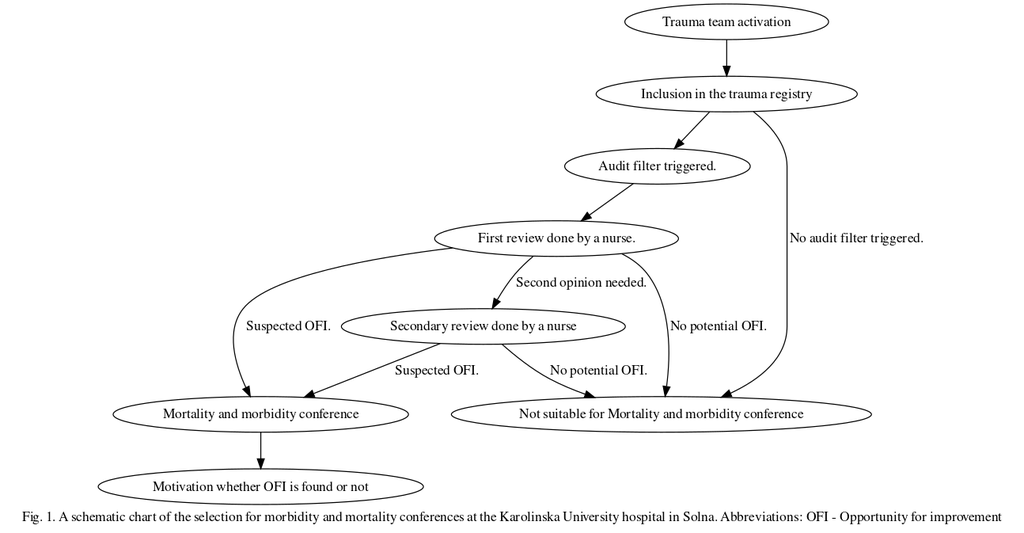

## Bias

To prevent research bias all data was scrambled while the analysis model was created. This means that the real data was not available throughout the process of writing the introduction or method. The scrambled data was also used for creating functions that later could be used on the real data in the final step to get the true results.

## Study size

A complete case analysis was done on all patients in the registries that met the inclusion criteria for this study.

## Quantitative variables

NISS, age and AIS codes were treated as continuous variables. The range of NISS was 1-75. Minor/Major was derived from the NISS value. NISS>15 was considered a Major Trauma and <15 a Minor Trauma. OFI had the values of either YES or NO.

The most severe region injured had 10 different values (found in the AIS codes): head, neck, face, thorax, upper extremity, lower extremity, abdomen, spine, multiple and unspecified. These 10 values were regrouped according to the ISS system into the following 7 cohorts.“Head and neck,” “Face,” “Chest, diaphragm or spine,” “Abdomen,” “Extremities,” “Unspecified” and “Multiple.”

For patients that had two or more different injuries and thereby multiple AIS codes, the most severe injury was selected. If more than one region had injuries of the same severity, the second most severe injury in those regions were compared, and then the third. If two or more regions had exactly the same pattern of injuries, the region was classified as “Multiple.”

## Statistical methods

For handling the data and conducting the statistical analysis the program R was used (35). First all data that was not needed for this study was removed, including columns with non essential information, patients without complete data, and those who did not meet the inclusion criteria. The frequencies of OFI for each subgroup was calculated by dividing the number of patients which had OFI with the total number of patients in that subgroup.

The difference (delta value) in OFI frequency between non-overlapping subgroups was calculated, meaning that the difference between for example men and women was calculated but not between women and patients with blunt trauma. Bootstrapping was used to estimate confidence intervals of frequencies and differences. The bootstrap procedure involved creating 1000 simulated data sets by resampling with replacement from the original dataset. The analyses were then repeated in these bootstrap samples and the confidence intervals for each estimate was calculated based on their distributions across bootstrap samples.

# Ethical considerations

As this is a study based on data from severely injured and deceased people, it must be considered a vulnerable patient group. Because of this it is extra important to carefully weigh the potential risks and benefits against each other when deciding if the study can be granted ethical permission.

In this case trauma patients were the patient group that needed to be studied, and therefor no other less vulnerable patient group would have been sufficient. This is however a registry based study, meaning that no interventions were made that could harm the patients. Measures was also taken to prevent personal information to be leaked about the patients. For example all data was scrambled for as long as possible, and to get access to the unscrambled data a virtual private network had to be used. Even then, the social security number of all patients was scrambled.

Patients included in the study not actively have given their consent or actively have said no to being included in the registries. This is common for trauma research as the patients often is not capable to making such a decision due to their injuries. This exception from patient consent is motivated by the fact that this kind of registry based research is in the public interest. However all patients have the right to request that their data is removed from the registries or sent a copy of the data stored about them in the registries.(36)

Despite the measures taken there is still a theoretical risk that a patient could be identified based on age, gender, trauma type and other information in the registries. The risk for this is however very small given the large number of patients and the limited number of people having access to the data.

Possible benefits from these type of studies are the possibility that the result can improve the trauma care and by that decrease morbidity and mortality for trauma patients by leading to further research based in the study results. Therefore the conclusion is that the potential risks of this study is overturned by the possible benefits.

Ethical permission has been granted for this project by the Stockholm Research Ethics Review Board. Approval number for this permission is 2021-02541 and 2021-0253.

# Results

## Participants

After merging the Karolinska trauma registry and the Trauma quality data base there was 11864 patients in the sample. After applying the inclusion criteria the number of patients was reduced to 6146 patients. Each step in the exclusion process is shown in the exclusion chart (fig. 2).

[figure not shown]

## Descriptive data

Table 1. A descriptive table of OFI percentage across all subgroups as well as the variables age, NISS and 30-day survival rate.

|  | Yes, atleast one opportunity for improvement (N=428) | No opportunities for improvement (N=5718) |
| --- | --- | --- |
| Age (years) |  |  |
| Median (Min, Max) | 47 (15, 97) | 42 (15, 100) |
| NISS |  |  |
| Median (Min, Max) | 23 (1, 75) | 11 (1, 75) |
| 30-day mortality rate |  |  |
| Deceased | 34 (7.94%) | 546 (9.55%) |
| Alive | 394 (92.1%) | 5172 (90.5%) |
| Gender |  |  |
| Male | 315 (73.6%) | 3980 (69.6%) |
| Female | 113 (26.4%) | 1738 (30.4%) |
| Dominating Type of Injury |  |  |
| Blunt | 365 (85.3%) | 4788 (83.7%) |
| Penetrating | 63 (14.7%) | 930 (16.3%) |
| Minor or Major Trauma |  |  |
| Minor Trauma | 113 (26.4%) | 3451 (60.4%) |
| Major Trauma | 315 (73.6%) | 2267 (39.6%) |
| The most severely injured body region |  |  |
| Head | 115 (26.9%) | 1387 (24.7%) |
| Neck | 3 (0.703%) | 172 (3.06%) |
| Face | 9 (2.11%) | 391 (6.97%) |
| Thorax | 89 (20.8%) | 898 (16.0%) |
| Spine | 41 (9.60%) | 485 (8.64%) |
| Abdomen | 49 (11.5%) | 336 (5.99%) |
| Lower Extremity | 81 (19.0%) | 939 (16.7%) |
| Upper Extremity | 16 (3.75%) | 407 (7.25%) |
| Unspeciefied | 0 (0%) | 0 (0%) |
| Multiple | 24 (5.62%) | 598 (10.7%) |
| Missing | 1 (0.2%) | 105 (1.8%) |

Abbreviations: NISS - The New Injury Severity Score. OFI - Opportunity for improvement.

## Main results

In the entire cohort of 6146 patients the mean frequency of OFI was 7%. Among the men the frequency of OFI was 7.33% (95% CI:( 6.59 - 8.1 )) and among the women 6.1% ( 5.04 - 7.16 ). Blunt trauma han an OFI frequency at 7.08% (95% CI:( 6.36 - 7.78 )) and penetrating trauma had an OFI frequency at 6.34 % (95% CI:( 4.88 - 7.82 )). Patients with minor trauma had an OFI frequency of 3.17% (95% CI:( 2.61 - 3.73 )) compared with the major trauma cohort which had an OFI frequency of 12.2% (95% CI:( 10.98 - 13.45 )). Across the most severely injured body region subgroup, OFI was most frequent in the abdomen cohort with a frequency of OFI at 12.73% (95% CI:( 9.52 - 16.08 )).The lowest OFI frequency was measured in the face cohort with a frequency of 2.25% (95% CI:( 0.72 - 3.77 )).

Table 2. A table showing the main results of this study. The OFI frequency is presented for each trauma subgroup as well as the 95% Confidence interval for each OFI frequency.

| Cohort | Frequency of OFI (%) | Confidence interval |
| --- | --- | --- |
| Men | 7.33 | ( 6.59 - 8.1 ) |
| Women | 6.1 | ( 5.04 - 7.16 ) |
| Blunt Trauma | 7.08 | ( 6.36 - 7.78 ) |
| Pentetraiting Trauma | 6.34 | ( 4.88 - 7.82 ) |
| Minor Trauma | 3.17 | ( 2.61 - 3.73 ) |
| Major Trauma | 12.2 | ( 10.98 - 13.45 ) |
| MSR - Head or Neck | 7.04 | ( 5.77 - 8.26 ) |
| MSR - Face | 2.25 | ( 0.72 - 3.77 ) |
| MSR - Chest, Diaphragm or Spine | 8.59 | ( 7.21 - 10.03 ) |
| MSR - Abdomen | 12.73 | ( 9.52 - 16.08 ) |
| MSR - Extremities | 6.72 | ( 5.42 - 8 ) |
| MSR - Multiple | 3.86 | ( 2.37 - 5.43 ) |

Abbreviations: MSR - Most severe region. OFI - Opportunity for improvement.

## Differences

Table 3. A table for the delta values for the Gender subgroup. The values in the parentheses is the 95% confidence interval for each delta value.

Men

Women

Women

1.23 ( -0.02 - 2.5 )

Men

-1.23 ( -2.5 - 0.02 )

Blunt Trauma

Penetrating Trauma

Penetrating Trauma

0.74 ( -0.89 - 2.33 )

Blunt Trauma

-0.74 ( -2.33 - 0.89 )

Minor Trauma

Major Trauma

Major Trauma

-9.03 ( -10.39 - -7.7 )

Minor Trauma

9.03 ( 7.7 - 10.39 )

Table 6. A table for the delta values for The Most Severly Injured Region subgroup. The values in the parentheses is the 95% confidence interval for each delta value.

Head or neck

Face

Chest, diaphragm or spine

Abdomen

Extremity

Multiple

Multiple

3.18 ( 1.1 - 5.13 )

-1.61 ( -3.82 - 0.51 )

4.73 ( 2.66 - 6.78 )

8.87 ( 5.28 - 12.5 )

2.86 ( 0.78 - 4.83 )

Extremity

0.31 ( -1.53 - 2.15 )

-4.47 ( -6.43 - -2.49 )

1.87 ( 0.05 - 3.77 )

6.01 ( 2.56 - 9.61 )

-2.86 ( -4.83 - -0.78 )

Abdomen

-5.69 ( -9.33 - -2.23 )

-10.48 ( -14.22 - -6.88 )

-4.14 ( -7.77 - -0.58 )

-6.01 ( -9.61 - -2.56 )

-8.87 ( -12.5 - -5.28 )

Chest, diaphragm or spine

-1.56 ( -3.53 - 0.31 )

-6.34 ( -8.4 - -4.35 )

4.14 ( 0.58 - 7.77 )

-1.87 ( -3.77 - -0.05 )

-4.73 ( -6.78 - -2.66 )

Face

4.79 ( 2.77 - 6.77 )

6.34 ( 4.35 - 8.4 )

10.48 ( 6.88 - 14.22 )

4.47 ( 2.49 - 6.43 )

1.61 ( -0.51 - 3.82 )

Head or neck

-4.79 ( -6.77 - -2.77 )

1.56 ( -0.31 - 3.53 )

5.69 ( 2.23 - 9.33 )

-0.31 ( -2.15 - 1.53 )

-3.18 ( -5.13 - -1.1 )

# Discussion

Today it is poorly understood wether the frequency of OFI varies between different trauma subgroups. The purpose of this study was therefore to asses the OFI Frequencies for some of the clinically important trauma subgroups in a registry based cohort study.

When comparing the results of this study with previous research one must keep in mind the fact that the OFI term is not a unanimously defined term between hospitals and that little trauma research exist that uses OFI as the primary outcome measure. It can however still be relevant to compare the result of this study with research looking into outcomes like preventable death, morbidity and mortality for the same trauma subgroups as this study.

As for the high frequency of OFI the Abdomen cohort, the results was rather unexpected. To the best of our knowledge there is no existing research indicating that abdominal trauma has ha higher frequency of OFI, mortality or preventable death. We can only speculate why this higher OFI frequency has been found. For example, one reason could be that those admitted to a level one trauma center with the abdomen as the most severely injured body region has suffered from a more extensive trauma then the other subgroups. It could also be that an abdominal trauma is not always as visually obvious in the pre hospital examinations or in the trauma room as the average head or thorax trauma for example. It can however be established that there is a statistically significant higher OFI frequency in the abdomen subgroup compared with the other body regions.

The find of a higher OFI frequency in major trauma compared with minor trauma is consistent with previous research. The mortality has been found to be higher in Major trauma cohort than in Minor trauma. (6). What also can be seen from previous studies is a correlation between major trauma and high preventable death(28,29). That major and complex trauma has ha greater risk for non optimal trauma care was also consistent with the our results, as the median NISS was higher in the OFI cohort then in the non OFI cohort.

It might however not be those with the highest NISS that has the very highest frequency of preventable deaths. Having the higest NISS, over 50 for example means that the patient suffers from extensive injuries and it is probably more obvious that everything than can be done should be done. If that is true, the OFI will be lower even if the mortality is high. Patients with major trauma but not as high NISS might on the other hand not be injured enough for it to be obvious that all resources available should be used to treat the patient. That will increase the OFI frequency.

In this this study though, a binary outcome measure was used by either classifying a trauma as minor or major with a cut off at NISS 15. Because of that, the spread of NISS among OFI patients will not be as nuanced as it potentially could have been.

Both data from SWETRAU and previous studies show that men are over represented as trauma patients.(22,37) Even though men in this study had a higher OFI frequency then women, the difference was not statistically significant. There is however previous research showing that men have a higher frequency of trauma mortality. Bolandparvaz et al fond that males had a higher risk for trauma mortality(37). Pape et al showed that females were less likely to die after trauma (38). Davoodabadi et al. found that there was no difference between the genders in preventable deaths after trauma (39). One explanation for these differences could be that men and women suffer from different kinds of trauma. For example the majority of penetraiting trauma patients are men (22).

## Strengths and limitations

There are several strengths in this study. For examlple, this study is to our knowledge the first study to look into OFI frequency among the selected trauma subgroups. The quality database that was used is to our knowledge also one of the largest databases that exist with data on living trauma patients. Another strength is that all programming and calculations was first done on scrambled data to minimize the risk for bias.

It can be considred both a strength and a limitation that all data come from the same context, namely the Karolinska University hospital in Solna. This means that strong conclusions can be made concerning the same hospital, and also for other similar Scandinavian level 1 trauma centers. On the other hand these results can most likely not be used to the same extent in other Swedish hospitals and even less in LMIC hospitals, which must be seen as a limitation. S

Another limitations in the study is the time frame. Data has been used that was collected from 2014 to 2021. It is likely that some trauma cases that had OFI back in 2014 would not have had OFI today. This due to changes in treatment and guidelines over the years. This time span was despite this necessary to get a large enough number of patients.

The audit filters that is a big part of the selection for M&M conferences is is not scientifically verified, but is instead based on experience from clinical experts and researchers. As there is no international or national consensus for what audit filters to use, each hospital rely on the expertise of their clinical professionals and scientists. It must also be considered a limitation that the selection for M&M conferences is partially done manually. This may lead to selection bias as well as bias due to the fact that it is not the same person that has been doing the selections since 2014.

As the total number of patients is relatively small, the size of some of the more uncommon trauma cohorts are very small, which is something one must keep in mind when studying the results. furthermore the delta values has for some cohorts a CI with quite a big range. This is most likely because of the low number of patients in these cohorts, making the delta value more sensitive to outliers.

## Clinical/Practical applications

This study may lead to increased awareness about which subgroups that has highest OFI frequencies. In turn that may lead to a more careful assessment and treatment of those types of traumas. Hopefully it will also lead to further research.

As for health equity there are several different aspects in this study to discuss. The fact that elderly patients also in this study are indicated to receive non optimal trauma care is notable. As described earlier, old age has been shown in multiple studies to be a disadvantage. Even if it to some extent is natural that older patient has a lower survival rate after trauma due to fragility and co morbidity. The fact that it was shown in a new and extensive american study that also the preventable death was significantly higher in elder is however problematic (25). Both in a moral aspect as well as in the eyes of the law, since everyone is entitled to the best care available.

It has also been shown in previous research that socioeconomic status like low income, low education and also co-morbidity are independent risk factors for trauma (40). The fact that co-morbidity is an independent risk factor might affect the generalizability since the results of this study may not apply to the part of the population without co-morbidity.

The fact that males are predominant as trauma patients may also affect the generalizability. This because there is not close to the same amount of data about females in most of the trauma subgroups. On the other hand this is probably not a major problem since research show that there is no difference between the genders when it comes to preventable death (39).

Another important aspect to discuss is the geographical differences in trauma care quality. As mentioned earlier in this paper, in Sweden there is a significantly higher chance of surviving a major trauma if you are treated at a trauma center compared with a non trauma center(3). By extension this means that people living in urban areas have a greater chance to survive then those who live in the more remote part of Sweden. Those differences are only the national ones. WHO said in 2012 that millions of lives could be saved annualy if the LMICs had the same level of trauma care as the high income countries (7).

## Future studies

In this study we assessed the frequency of OFI for different trauma subgroups. By knowing which trauma subgroups that has the highest OFI frequency it is possible to focus further research on these subgroups. That could for example be done by a registry based cohort study of what kind of OFIs that are the most frequent ones for the different subgroups. There could potentially be varying OFI problem areas for different subgroups leading to diverse outcomes in terms of morbidity and mortality.

It would also be interesting to investigate potential risk factors for OFI. This could be done by comparing factors like pre hospital vitals, time to arrival at the trauma center and co-morbidity to name a few. By knowing what kind of risk factors that increase the risk for OFI, OFI could in some cases potentially be prevented. This kind of study could also be done as a registry based cohort study using the same trauma registries as our study.

## Conclusion

# References

1.

Gerdin M. The risk of dying. [cited 2022 Sep 23]; Available from: https://openarchive.ki.se/xmlui/handle/10616/44832

2.

GBD 2017 Causes of Death Collaborators. Global, regional, and national age-sex-specific mortality for 282 causes of death in 195 countries and territories, 1980-2017: A systematic analysis for the global burden of disease study 2017. Lancet. 2018 Nov;392(10159):1736–88.

3.

Candefjord S, Asker L, Caragounis E-C. Mortality of trauma patients treated at trauma centers compared to non-trauma centers in sweden: A retrospective study. Eur J Trauma Emerg Surg. 2022 Feb;48(1):525–36.

4.

Drake SA, Holcomb JB, Yang Y, Thetford C, Myers L, Brock M, et al. Establishing a regional trauma preventable/potentially preventable death rate. Ann Surg. 2020 Feb;271(2):375–82.

5.

Ray JJ, Meizoso JP, Satahoo SS, Davis JS, Van Haren RM, Dermer H, et al. Potentially preventable prehospital deaths from motor vehicle collisions. Traffic Inj Prev. 2016 Oct;17(7):676–80.

6.

Ghorbani P, Strömmer L. Analysis of preventable deaths and errors in trauma care in a scandinavian trauma level-i centre. Acta Anaesthesiol Scand. 2018 Sep;62(8):1146–53.

7.

Mock C, Joshipura M, Arreola-Risa C, Quansah R. An estimate of the number of lives that could be saved through improvements in trauma care globally. World J Surg. 2012 May;36(5):959–63.

8.

Mock C. WHO releases guidelines for trauma quality improvement programmes. Inj Prev. 2009 Oct;15(5):359.

9.

Hemmila MR, Nathens AB, Shafi S, Calland JF, Clark DE, Cryer HG, et al. The trauma quality improvement program: Pilot study and initial demonstration of feasibility. J Trauma. 2010 Feb;68(2):253–62.

10.

Blackmore AR, Leonard J, Madayag R, Bourg PW. Using the trauma quality improvement program metrics data to enhance clinical practice. J Trauma Nurs. 2019 May;26(3):121–7.

11.

Aboumatar HJ, Blackledge CG Jr, Dickson C, Heitmiller E, Freischlag J, Pronovost PJ. A descriptive study of morbidity and mortality conferences and their conformity to medical incident analysis models: Results of the morbidity and mortality conference improvement study, phase 1. Am J Med Qual. 2007 Jul;22(4):232–8.

12.

Evans C, Howes D, Pickett W, Dagnone L. Audit filters for improving processes of care and clinical outcomes in trauma systems. Cochrane Database Syst Rev. 2009 Oct;(4):CD007590.

13.

Berg J, Alvesson HM, Roy N, Ekelund U, Bains L, Chatterjee S, et al. Perceived usefulness of trauma audit filters in urban india: A mixed-methods multicentre delphi study comparing filters from the WHO and low and middle-income countries. BMJ Open. 2022 Jun;12(6):e059948.

14.

Kuo SCH, Kuo P-J, Chen Y-C, Chien P-C, Hsieh H-Y, Hsieh C-H. Comparison of the new exponential injury severity score with the injury severity score and the new injury severity score in trauma patients: A cross-sectional study. PLoS One. 2017 Nov;12(11):e0187871.

15.

Javali RH, Krishnamoorthy, Patil A, Srinivasarangan M, Suraj, Sriharsha. Comparison of injury severity score, new injury severity score, revised trauma score and trauma and injury severity score for mortality prediction in elderly trauma patients. Indian J Crit Care Med. 2019 Feb;23(2):73–7.

16.

Li H, Ma Y-F. New injury severity score (NISS) outperforms injury severity score (ISS) in the evaluation of severe blunt trauma patients. Chin J Traumatol. 2021 Sep;24(5):261–5.

17.

Bagher A, Todorova L, Andersson L, Wingren CJ, Ottosson A, Wangefjord S, et al. Analysis of pre-hospital rescue times on mortality in trauma patients in a scandinavian urban setting. Trauma. 2017 Jan;19(1):28–34.

18.

Sanddal TL, Esposito TJ, Whitney JR, Hartford D, Taillac PP, Mann NC, et al. Analysis of preventable trauma deaths and opportunities for trauma care improvement in utah. J Trauma. 2011 Apr;70(4):970–7.

19.

WHO, International society of surgery and International Association for Trauma Surgery and Intensive Care. Guidelines for trauma quality improvement programmes. 2009 [cited 2022 Sep 23]; Available from: https://apps.who.int/iris/bitstream/handle/10665/44061/9789241597746_eng.pdf?sequence=1&isAllowed=y

20.

Montmany S, Pallisera A, Rebasa P, Campos A, Colilles C, Luna A, et al. Preventable deaths and potentially preventable deaths. What are our errors? Injury. 2016 Mar;47(3):669–73.

21.

Coats T. Blunt major trauma: Now two different diseases? Br J Hosp Med (Lond). 2020 Apr;81(4):1–3.

22.

Svenska traumaregistret (SweTrau). Årsrapport 2021. [cited 2022 Sep 23]; Available from: https://rcsyd.se/swetrau/om-swetrau/arsrapporter

23.

O’Reilly D, Mahendran K, West A, Shirley P, Walsh M, Tai N. Opportunities for improvement in the management of patients who die from haemorrhage after trauma. British Journal of Surgery [Internet]. 2013 Mar;100(6):749–55. Available from: http://dx.doi.org/10.1002/bjs.9096

24.

Chambers JA, Seastedt K, Krell R, Caterson E, Levy M, Turner N. “Stop the bleed”: A u.s. Military installation’s model for implementation of a rapid hemorrhage control program. Mil Med. 2019 Mar;184(3-4):67–71.

25.

Ang D, Nieto K, Sutherland M, O’Brien M, Liu H, Elkbuli A. Understanding preventable deaths in the geriatric trauma population: Analysis of 3,452,339 patients from the center of medicare and medicaid services database. Am Surg. 2022 Apr;88(4):587–96.

26.

Adams SD, Cotton BA, McGuire MF, Dipasupil E, Podbielski JM, Zaharia A, et al. Unique pattern of complications in elderly trauma patients at a level I trauma center. J Trauma Acute Care Surg. 2012 Jan;72(1):112–8.

27.

28.

Schoeneberg C, Schilling M, Hussmann B, Schmitz D, Lendemans S, Ruchholtz S. Preventable and potentially preventable deaths in severely injured patients: A retrospective analysis including patterns of errors. Eur J Trauma Emerg Surg. 2017 Aug;43(4):481–9.

29.

Kleber C, Giesecke MT, Tsokos M, Haas NP, Buschmann CT. Trauma-related preventable deaths in berlin 2010: Need to change prehospital management strategies and trauma management education. World J Surg. 2013 May;37(5):1154–61.

30.

Svenska traumaregistret (SweTrau). THE SWEDISH TRAUMA REGISTRY (SWETRAU). [cited 2022 Sep 23]; Available from: https://rcsyd.se/swetrau/om-swetrau/about-swetrau-in-english/swetrau-the-swedish-trauma-registry

31.

Karolinska University Hospital Press Officer. Karolinska university hospital is the eighth best hospital in the world. [cited 2022 Sep 23]; Available from: https://news.cision.com/karolinska-universitetssjukhuset/r/karolinska-university-hospital-is-the-eighth-best-hospital-in-the-world,c3517653

32.

Linda Axelsson, Gunnar Sandersjöö. Traumacentrum. [cited 2022 Sep 23]; Available from: https://www.karolinska.se/for-vardgivare/tema-akut-och-reparativ-medicin/trauma-akutkirurgi-och-ortopedi/traumacentrum/

33.

Almskog LM, Hammar U, Wikman A, Östlund A, Svensson J, Wanecek M, et al. A retrospective register study comparing fibrinogen treated trauma patients with an injury severity score matched control group. Scand J Trauma Resusc Emerg Med. 2020 Jan;28(1):5.

34.

Granström A, Wihlke G, Brattström O, Ostlund A. [Activation of the trauma team is related to injury severity. Triage stringency can yield optimal use of resources]. Lakartidningen. 2012;109(4):154–7.

35.

R Core Team. R: A language and environment for statistical computing [Internet]. Vienna, Austria: R Foundation for Statistical Computing; 2020. Available from: https://www.R-project.org/

36.

Svenska Traumaregistret (SweTrau). Du bidrar till en bättre vård! [Internet]. 2022 [cited 2022 Dec 17]. Available from: https://rcsyd.se/swetrau/wp-content/uploads/sites/10/2019/09/Patientinformation-SweTrau.pdf?fbclid=IwAR2UEOeGLL9SeEBYC5961nMZDUhlk337qPldyqA9-Yox85NmbeV_l7V3PDw

37.

Bolandparvaz S, Yadollahi M, Abbasi HR, Anvar M. Injury patterns among various age and gender groups of trauma patients in southern iran. Medicine (Baltimore). 2017 Oct;96(41):e7812.

38.

Pape M, Giannakópoulos GF, Zuidema WP, Lange-Klerk ESM de, Toor EJ, Edwards MJR, et al. Is there an association between female gender and outcome in severe trauma? A multi-center analysis in the netherlands. Scand J Trauma Resusc Emerg Med. 2019 Feb;27(1):16.

39.

Davoodabadi A, Abdorrahim Kashi E, Mohammadzadeh M, Mousavi N, Shafagh S, Ghafoor L, et al. Predicting factors and incidence of preventable trauma induced mortality. Ann Med Surg (Lond). 2021 Aug;68(102609):102609.

40.

Brattström O, Eriksson M, Larsson E, Oldner A. Socio-economic status and co-morbidity as risk factors for trauma. Eur J Epidemiol. 2015 Feb;30(2):151–7.